# Analisis Performa Genre Film dan Perilaku Customer pada Sakila Database

# 3 Segmentasi Customer (K-Means Clustering)

```
##   rental_count   total_payment
##  Min.   :12.00   Min.   : 50.85
##  1st Qu.:23.00   1st Qu.: 94.78
##  Median :26.00   Median :110.73
##  Mean   :26.78   Mean   :112.53
##  3rd Qu.:30.00   3rd Qu.:128.71
##  Max.   :46.00   Max.   :221.55
```

```
##
## Total pelanggan: 599
```

```
## Setelah normalisasi:
```

```
##   Mean rental_count : 0
```

```
##   SD   rental_count : 1
```

```
##   Mean total_payment: 0
```

```
##   SD   total_payment: 1
```

## 3.1 Jumlah Klaster Optimal (Elbow Method)

$$WSS = \sum_{k=1}^{K} \sum_{x_i \in C_k} \|x_i - \mu_k\|^2$$

*di mana* $\mu_k$ adalah centroid klaster ke-$k$ dan $C_k$ adalah himpunan titik data dalam klaster ke-$k$.

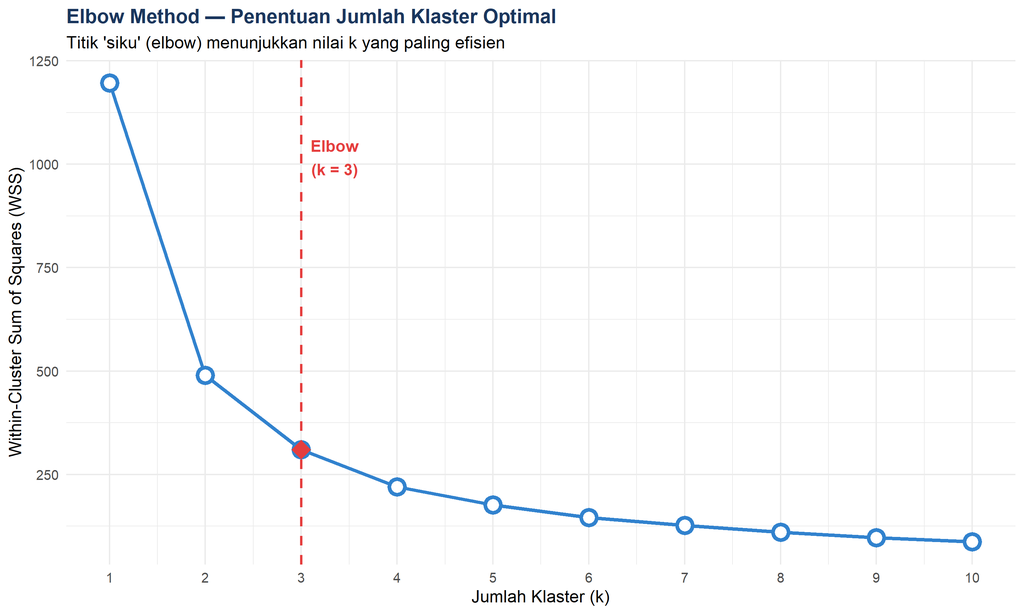

Gambar 4. Elbow Method untuk Menentukan Jumlah Klaster Optimal

```r
set.seed(42)
wss_values <- sapply(1:10, function(k) {
  kmeans(cluster_scaled, centers = k, nstart = 25, iter.max = 100)$tot.withinss
})

elbow_df <- data.frame(k = 1:10, wss = wss_values)

ggplot(elbow_df, aes(x = k, y = wss)) +
  geom_line(color = "#3182ce", linewidth = 1.2) +
  geom_point(color = "#3182ce", size = 4, fill = "white", shape = 21, stroke = 2) +
  geom_point(data = elbow_df[elbow_df$k == 3, ],
             color = "#e53e3e", size = 6, shape = 18) +
  geom_vline(xintercept = 3, linetype = "dashed", color = "#e53e3e", linewidth = 0.8) +
  annotate("text", x = 3.35, y = max(wss_values) * 0.85,
           label = "Elbow\n(k = 3)", color = "#e53e3e", fontface = "bold", size = 4) +
  scale_x_continuous(breaks = 1:10) +
  labs(
    title    = "Elbow Method — Penentuan Jumlah Klaster Optimal",
    subtitle = "Titik 'siku' (elbow) menunjukkan nilai k yang paling efisien",
    x        = "Jumlah Klaster (k)",
    y        = "Within-Cluster Sum of Squares (WSS)"
  ) +
  theme_minimal(base_size = 12) +
  theme(
    plot.title      = element_text(face = "bold", size = 14, color = "#1a365d"),
    plot.background = element_rect(fill = "white", color = NA)
  )
```

#### 📌 Interpretasi: Elbow Method

- WSS mengukur total variasi data di dalam setiap klaster. Semakin kecil WSS, semakin homogen pelanggan dalam satu klaster.
- Penurunan WSS paling tajam terjadi pada transisi $k=1 \to k=2$ dan $k=2 \to k=3$. Setelah $k=3$, penurunan mulai melandai — membentuk “siku” (*elbow*).
- **Keputusan:** $k=3$ dipilih sebagai jumlah klaster optimal karena menangkap sebagian besar variabilitas data tanpa menambah kompleksitas yang tidak perlu.